# Live Session 2

## 1.3 Expectation is Linear

Remember that for a RV $X$ and constants $a$ and $b$, $\mathbb{E}(aX + b) = a\mathbb{E}X + b$

Later, we’ll also see that for two random variables $X$ and $Y$, $\mathbb{E}(X + Y) = \mathbb{E}X + \mathbb{E}Y$.

Linearity is a very powerful property. Using it can often make your solutions much cleaner.

Say you want to find the expectation of a symmetric variable, $X$. For example, here’s a random variable that’s symmetric around 5.

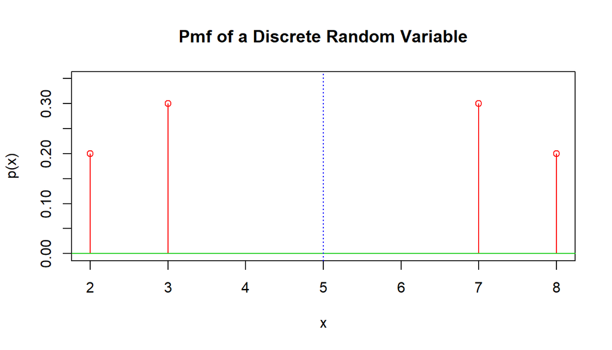

```r
options(repr.plot.width=4, repr.plot.height=3)
plot(c(2,3,7,8),c(.2,.3,.3,.2),type="h",col=2,main="Pmf of a Discrete Random Variable",xlab="x",ylab="p(x)",ylim=c(0,.35))
points(c(2,3,7,8),c(.2,.3,.3,.2),col=2)
abline(h=0,col=3)
abline(v=5,col=4, lty=3)
```

To find the expectation, you could write the expectation as a sum in terms of the probability mass function (pmf), and then break the sum up into two sums… but it gets a bit messy.

Instead, you can try to apply linearity. First, think of a function, $f$, such that $f(X)$ is another random variable with the exact same pmf as $X$. ($f(x)=x$ is one function that does this, but it doesn’t help you, so you need to think of another function).

Now, write the equation that says that the expectation of $X$ and $f(X)$ are the same, and simplify it.

## 1.4 Simulation

#### 1.4 Exercise:

In what ways are simulations useful to a data scientist?

**Answer**

If we do not have a closed-form mathematical formula, we often can simulate RV output and still describe the underlying distribution numerically (via computed mean, variance, etc.).

If you have an algorithm that works well for a specific distribution and you want to demonstrate your results, then you need values from that distribution.

#### 1.4 Exercise:

A binomial variable can be used to model a set of independent trials. Say that you have a coin that lands heads with probability $p$. You flip the coin $n$ times. A binomial variable with parameters $n$ and $p$ is defined as the number of heads out of the $n$ flips.

Use R to simulate the $100$ flips for a coin with $p=.3$ and output the number of heads.

**Answer**

```r
x = seq(0,50,by=1)
y = dbinom(x, size = 100,prob=.3)
```

Plot the above distribution. What other famous distribution does it remind you of?

#### 1.4 Exercise:

You have just taken a single draw from your random variable. If you want to see what the distribution of your variable looks like, one idea is to simulate many draws.

**Answer**

Use R to repeat the simulation 1000 times and store the value of the random variable each time. Plot a histogram of your result.